# Unificação dos Dados MEI

# Introdução

Este relatório apresenta uma análise exploratória dos CNAEs mais frequentes entre os Microempreendedores Individuais (MEIs) em Parnaíba. O objetivo é identificar o perfil empreendedor local, comparando com tendências setoriais e hipóteses sobre a vocação econômica da região.

# Análise

Primeiramente devemos importar e ler os dados, logo em seguida, é necessário filtrar pelo município Parnaíba:

## 1. Top 3 CNAEs

Identificamos os três CNAEs com maior número de MEIs em Parnaíba. Esses setores representam a base do empreendedorismo individual no município.

Top 3 CNAEs de MEIs – Parnaíba-PI

| CNAE | OCUPAÇÃO | TOTAL | PERCENTUAL |
| --- | --- | --- | --- |
| 4781400 | COMERCIANTE DE ARTIGOS DO VESTUÁRIO E ACESSÓRIOS INDEPENDENTE | 716 | 5.3% |
| 9602501 | BARBEIRO INDEPENDENTE | 411 | 3.0% |
| 9602501 | CABELEIREIRO(A) INDEPENDENTE | 411 | 3.0% |

## 2. Concentração ou dispersão?

Para entender se o empreendedorismo local se concentra em poucos setores ou é mais distribuído, calculamos a participação dos 3 maiores CNAEs no total.

Participação dos 3 Maiores CNAEs

| Total de MEIs em Parnaíba | Total dos Top 3 CNAEs | Participação dos Top 3 |
| --- | --- | --- |
| 13.569 | 1.538 | 11.3% |

## 3. Perfil encontrado

A participação dos 3 maiores CNAEs representa apenas 11.3% do total de MEIs em Parnaíba. Esse valor está bem abaixo do limiar de 40%, indicando dispersão. Em outras palavras, a atividade empreendedora local é diversificada, distribuída entre vários setores, sem que apenas poucos segmentos concentrem a maior parte dos registros. Além dos líderes, também analisamos como o restante dos CNAEs se distribui.

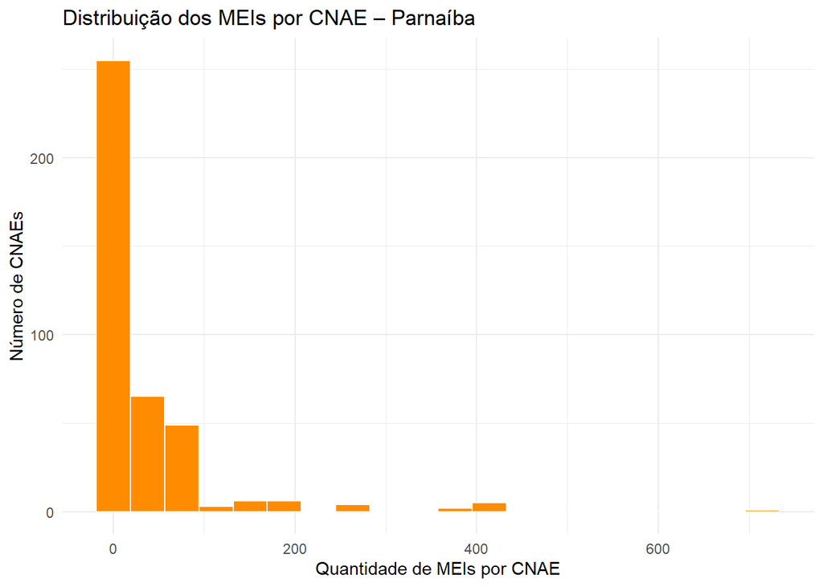

O histograma evidencia que o empreendedorismo individual em Parnaíba é altamente pulverizado. A maior parte dos CNAEs reúne menos de 20 registros de MEIs, enquanto apenas alguns poucos chegam a centenas. Isso reforça a ideia de diversidade de setores, sem predominância forte de poucos segmentos.

## Hipóteses para a economia local

- **Vocação para comércio de bairro e serviços básicos:** predominância de vestuário, mercearias e beleza indica um mercado voltado ao atendimento da população local.
- **Turismo como indutor de serviços:** restaurantes, lanchonetes, casas de sucos e salões de beleza também podem estar ligados à demanda de turistas no Delta do Parnaíba.
- **Economia de subsistência e microescala:** a dispersão dos CNAEs e as baixas barreiras de entrada sugerem empreendimentos com capital inicial reduzido, sustentando o dia a dia de famílias.
- **Setor de alimentação como motor empreendedor:** confirmando tendências nacionais, alimentação fora do lar é um dos setores mais relevantes no MEI, por ser de rápido retorno financeiro.
- **Prestação de serviços informais formalizados:** panfletagem e promoção de vendas refletem atividades que já existiam na informalidade e passaram a ser registradas como MEI.

## 4. Considerando a UF

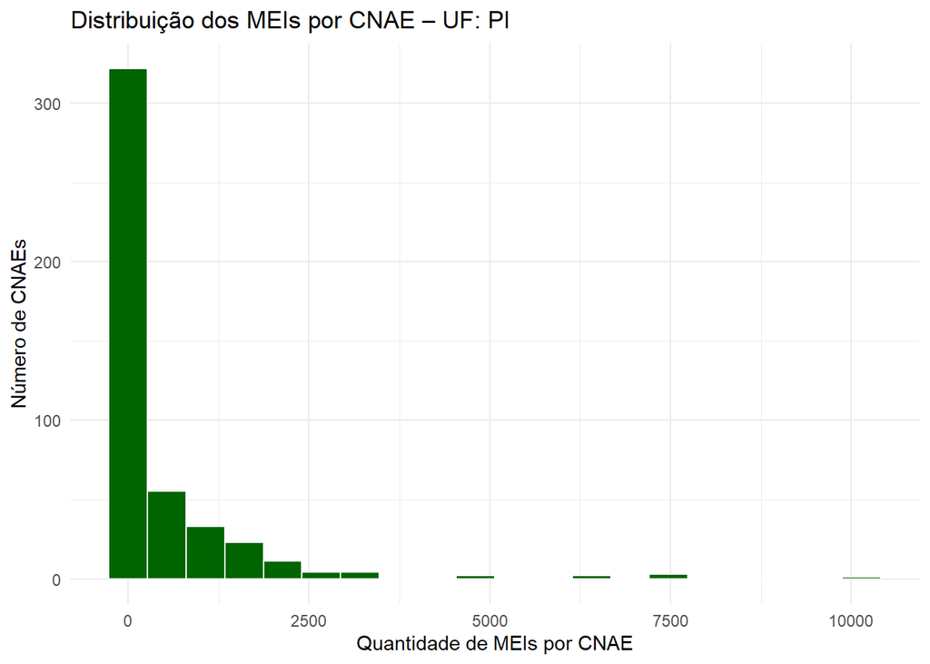

## 5.Limitações

- A análise se baseia em um recorte estático, sem considerar evolução ao longo do tempo.
- O relatório da Receita pode apresentar inconsistências de classificação ou agrupamentos distintos sob o mesmo CNAE.
- Como a base é agregada por município, não permite detalhar perfis individuais de empreendedores (idade, gênero, renda, etc.).
- Os resultados dependem da qualidade do CSV gerado no site, o que pode variar conforme a forma de exportação.